# R coursework with Sumeet

3rd : Introduction to dplyr

Yura Song

April 09, 2020

# Preparation

```r
library(tidyverse)
```

We will keep working on **Tidy datasets**, composed of variables, observations and values.

# Dataset - mtcars

The dataset we will use today is called **mtcars**. This data was extracted from US motors magazine, composed of 32 observations on 11 numeric variables.

## Getting glimpse of the data

```r
summary(mtcars)
```

```
      mpg             cyl             disp             hp
 Min.   :10.40   Min.   :4.000   Min.   : 71.1   Min.   : 52.0
 1st Qu.:15.43   1st Qu.:4.000   1st Qu.:120.8   1st Qu.: 96.5
 Median :19.20   Median :6.000   Median :196.3   Median :123.0
 Mean   :20.09   Mean   :6.188   Mean   :230.7   Mean   :146.7
 3rd Qu.:22.80   3rd Qu.:8.000   3rd Qu.:326.0   3rd Qu.:180.0
 Max.   :33.90   Max.   :8.000   Max.   :472.0   Max.   :335.0
      drat             wt             qsec             vs
 Min.   :2.760   Min.   :1.513   Min.   :14.50   Min.   :0.0000
 1st Qu.:3.080   1st Qu.:2.581   1st Qu.:16.89   1st Qu.:0.0000
 Median :3.695   Median :3.325   Median :17.71   Median :0.0000
 Mean   :3.597   Mean   :3.217   Mean   :17.85   Mean   :0.4375
 3rd Qu.:3.920   3rd Qu.:3.610   3rd Qu.:18.90   3rd Qu.:1.0000
 Max.   :4.930   Max.   :5.424   Max.   :22.90   Max.   :1.0000
       am              gear            carb
 Min.   :0.0000   Min.   :3.000   Min.   :1.000
 1st Qu.:0.0000   1st Qu.:3.000   1st Qu.:2.000
 Median :0.0000   Median :4.000   Median :2.000
 Mean   :0.4062   Mean   :3.688   Mean   :2.812
 3rd Qu.:1.0000   3rd Qu.:4.000   3rd Qu.:4.000
 Max.   :1.0000   Max.   :5.000   Max.   :8.000
```

Or we could use *View()* to see the dataframe as a format of table. Compared to *summary()*, it is much easier to go through the dataset and sorting the values are available. Also, you could filter the datasets as a part of datasets.

```r
View(mtcars)
```

Also, we could see the structure of each column with *str()*. This also provides a glimpse for the dataset.

```r
str(mtcars)
```

```
'data.frame':   32 obs. of  11 variables:
 $ mpg : num  21 21 22.8 21.4 18.7 18.1 14.3 24.4 22.8 19.2 ...
 $ cyl : num  6 6 4 6 8 6 8 4 4 6 ...
 $ disp: num  160 160 108 258 360 ...
 $ hp  : num  110 110 93 110 175 105 245 62 95 123 ...
 $ drat: num  3.9 3.9 3.85 3.08 3.15 2.76 3.21 3.69 3.92 3.92 ...
 $ wt  : num  2.62 2.88 2.32 3.21 3.44 ...
 $ qsec: num  16.5 17 18.6 19.4 17 ...
 $ vs  : num  0 0 1 1 0 1 0 1 1 1 ...
 $ am  : num  1 1 1 0 0 0 0 0 0 0 ...
 $ gear: num  4 4 4 3 3 3 3 4 4 4 ...
 $ carb: num  4 4 1 1 2 1 4 2 2 4 ...
```

If we would like to know the size of dataset, we could use *dim()* function.

```r
dim(mtcars)
```

```
[1] 32 11
```

For the number of rows or columns, the function *nrow()* or *ncol()* will work!

```r
nrow(mtcars)
```

```
[1] 32
```

For getting the names of column or row, we could take them by using *colnames()* or *rownames()*.

```r
colnames(mtcars)
```

```
 [1] "mpg"  "cyl"  "disp" "hp"   "drat" "wt"   "qsec" "vs"   "am"
[10] "gear" "carb"
```

```r
rownames(mtcars)
```

```
 [1] "Mazda RX4"           "Mazda RX4 Wag"       "Datsun 710"
 [4] "Hornet 4 Drive"      "Hornet Sportabout"   "Valiant"
 [7] "Duster 360"          "Merc 240D"           "Merc 230"
[10] "Merc 280"            "Merc 280C"           "Merc 450SE"
[13] "Merc 450SL"          "Merc 450SLC"         "Cadillac Fleetwood"
[16] "Lincoln Continental" "Chrysler Imperial"   "Fiat 128"
[19] "Honda Civic"         "Toyota Corolla"      "Toyota Corona"
[22] "Dodge Challenger"    "AMC Javelin"         "Camaro Z28"
[25] "Pontiac Firebird"    "Fiat X1-9"           "Porsche 914-2"
[28] "Lotus Europa"        "Ford Pantera L"      "Ferrari Dino"
[31] "Maserati Bora"       "Volvo 142E"
```

Subsetting based on the rows is possible by giving the name of rows.

|  | mpg | cyl | disp | hp | drat | wt | qsec | vs | am | gear | carb |
| --- | --- | --- | --- | --- | --- | --- | --- | --- | --- | --- | --- |
| Mazda RX4 | 21 | 6 | 160 | 110 | 3.9 | 2.620 | 16.46 | 0 | 1 | 4 | 4 |
| Mazda RX4 Wag | 21 | 6 | 160 | 110 | 3.9 | 2.875 | 17.02 | 0 | 1 | 4 | 4 |

## Correlation

To see the correlation between each elements, we could use *plot()*.

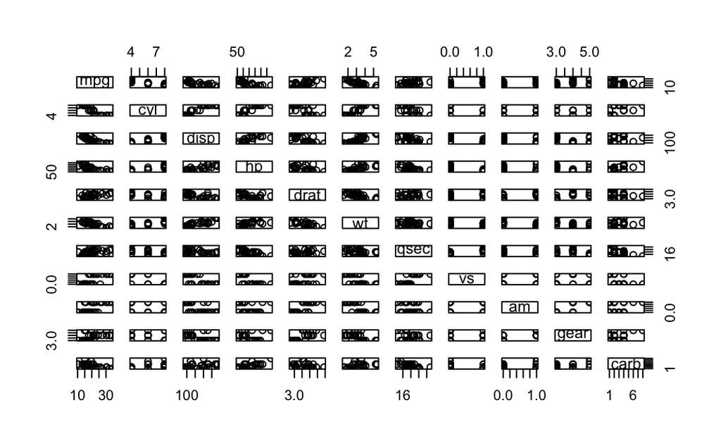

```r
plot(mtcars)
```

Also, if we would like to get the **correlation coefficient** between two different element in the dataset, we could use *cor()* function. Here, we should declare which element we would like to see. The default method is Pearson.

```r
cor(x=mtcars$mpg, y=mtcars$hp)
```

```
[1] -0.7761684
```

If we would like to use different method to calculate correlation coefficient, we could specify method.

```r
cor(x=mtcars$mpg, y=mtcars$hp, method="spearman")
```

```
[1] -0.8946646
```

If we give a subset of columns, it will return the correlation as a format of table.

```r
cor(mtcars[, c(1, 4)])
```

```
           mpg         hp
mpg  1.0000000 -0.7761684
hp  -0.7761684  1.0000000
```

Also, correlation between all columns could be calculated too!

```r
cor(mtcars)
```

```
            mpg        cyl       disp         hp        drat         wt
mpg   1.0000000 -0.8521620 -0.8475514 -0.7761684  0.68117191 -0.8676594
cyl  -0.8521620  1.0000000  0.9020329  0.8324475 -0.69993811  0.7824958
disp -0.8475514  0.9020329  1.0000000  0.7909486 -0.71021393  0.8879799
hp   -0.7761684  0.8324475  0.7909486  1.0000000 -0.44875912  0.6587479
drat  0.6811719 -0.6999381 -0.7102139 -0.4487591  1.00000000 -0.7124406
wt   -0.8676594  0.7824958  0.8879799  0.6587479 -0.71244065  1.0000000
qsec  0.4186840 -0.5912421 -0.4336979 -0.7082234  0.09120476 -0.1747159
vs    0.6640389 -0.8108118 -0.7104159 -0.7230967  0.44027846 -0.5549157
am    0.5998324 -0.5226070 -0.5912270 -0.2432043  0.71271113 -0.6924953
gear  0.4802848 -0.4926866 -0.5555692 -0.1257043  0.69961013 -0.5832870
carb -0.5509251  0.5269883  0.3949769  0.7498125 -0.09078980  0.4276059
            qsec         vs          am       gear        carb
mpg   0.41868403  0.6640389  0.59983243  0.4802848 -0.55092507
cyl  -0.59124207 -0.8108118 -0.52260705 -0.4926866  0.52698829
disp -0.43369788 -0.7104159 -0.59122704 -0.5555692  0.39497686
hp   -0.70822339 -0.7230967 -0.24320426 -0.1257043  0.74981247
drat  0.09120476  0.4402785  0.71271113  0.6996101 -0.09078980
wt   -0.17471588 -0.5549157 -0.69249526 -0.5832870  0.42760594
qsec  1.00000000  0.7445354 -0.22986086 -0.2126822 -0.65624923
vs    0.74453544  1.0000000  0.16834512  0.2060233 -0.56960714
am   -0.22986086  0.1683451  1.00000000  0.7940588  0.05753435
gear -0.21268223  0.2060233  0.79405876  1.0000000  0.27407284
carb -0.65624923 -0.5696071  0.05753435  0.2740728  1.00000000
```

## Statistical test

### T-test

Does mpg differ based on Engine? We will see one by one. First, we will visualize data with **boxplot**.

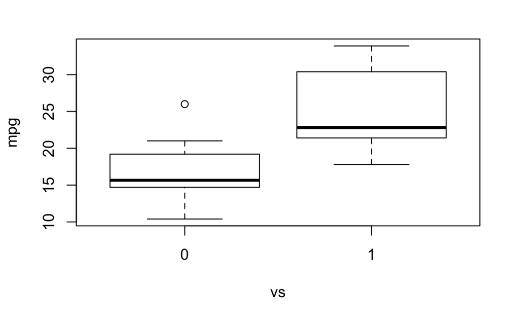

Well, it looks quite different between each other. Here, to see their difference is significant or not, we will do *t.test()*.

```r
t.test(formula = mpg ~ vs, data = mtcars)
```

```
    Welch Two Sample t-test

data:  mpg by vs
t = -4.6671, df = 22.716, p-value = 0.0001098
alternative hypothesis: true difference in means is not equal to 0
95 percent confidence interval:
 -11.462508  -4.418445
sample estimates:
mean in group 0 mean in group 1
       16.61667        24.55714
```

### ANOVA

Before starting analysis, we could make the element as a table. With function called *table()*, we could check the levels and number of observations.

```r
table(mtcars$gear)
```

```
 3  4  5
15 12  5
```

Here, we would like to see whether the differences between gear is significant or not.

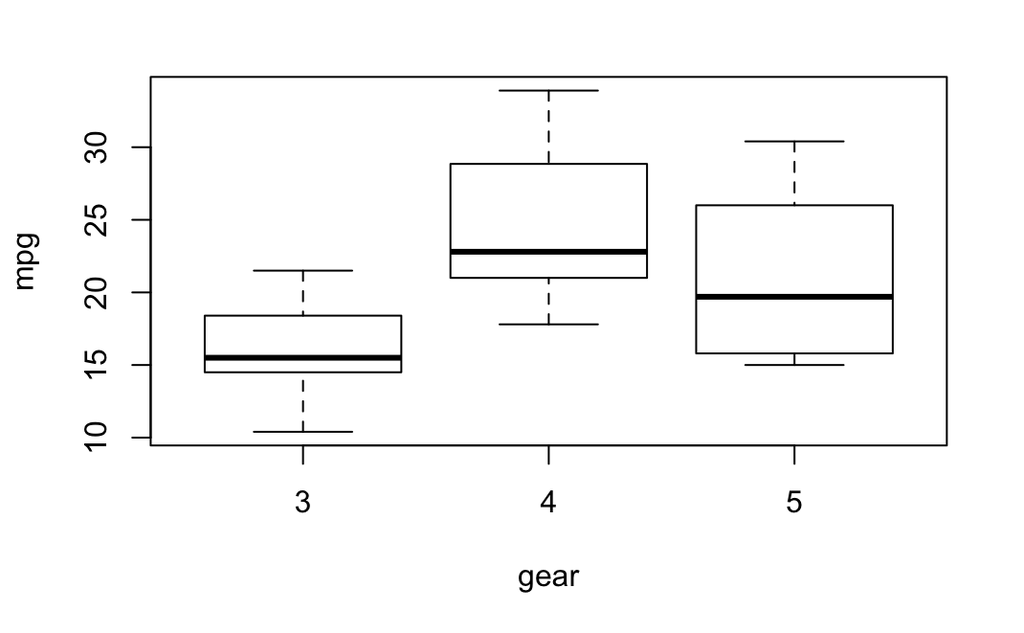

Here, we will perform ANOVA. The function for ANOVA is *aov()*.

```r
mpg.model <- aov(formula = mpg ~ gear, data = mtcars)
summary(mpg.model)
```

```
            Df Sum Sq Mean Sq F value Pr(>F)
gear         1  259.7  259.75   8.995 0.0054 **
Residuals   30  866.3   28.88
---
Signif. codes:  0 ‘***’ 0.001 ‘**’ 0.01 ‘*’ 0.05 ‘.’ 0.1 ‘ ’ 1
```

It seems that we made mistake, the **Df** is a lot different.

```r
str(mtcars)
```

```
'data.frame':   32 obs. of  11 variables:
 $ mpg : num  21 21 22.8 21.4 18.7 18.1 14.3 24.4 22.8 19.2 ...
 $ cyl : num  6 6 4 6 8 6 8 4 4 6 ...
 $ disp: num  160 160 108 258 360 ...
 $ hp  : num  110 110 93 110 175 105 245 62 95 123 ...
 $ drat: num  3.9 3.9 3.85 3.08 3.15 2.76 3.21 3.69 3.92 3.92 ...
 $ wt  : num  2.62 2.88 2.32 3.21 3.44 ...
 $ qsec: num  16.5 17 18.6 19.4 17 ...
 $ vs  : num  0 0 1 1 0 1 0 1 1 1 ...
 $ am  : num  1 1 1 0 0 0 0 0 0 0 ...
 $ gear: num  4 4 4 3 3 3 3 4 4 4 ...
 $ carb: num  4 4 1 1 2 1 4 2 2 4 ...
```

Well, gear is still as numeric value, not factor. Since the values on gear indicate the group, so we should give it as a **factor** in the model, not numeric values. If not, it will be considered as continuous values.

```r
mpg.model <- aov(formula = mpg ~ factor(gear), data = mtcars)
summary(mpg.model)
```

```
             Df Sum Sq Mean Sq F value   Pr(>F)
factor(gear)  2  483.2  241.62    10.9 0.000295 ***
Residuals    29  642.8   22.17
---
Signif. codes:  0 ‘***’ 0.001 ‘**’ 0.01 ‘*’ 0.05 ‘.’ 0.1 ‘ ’ 1
```

Here, also, we could see the pair-wise comparison. The model which we have used for ANOVA is given as input in *TukeyHSD()*.

```r
TukeyHSD(mpg.model)
```

```
  Tukey multiple comparisons of means
    95% family-wise confidence level

Fit: aov(formula = mpg ~ factor(gear), data = mtcars)

$`factor(gear)`
         diff        lwr       upr     p adj
4-3  8.426667  3.9234704 12.929863 0.0002088
5-3  5.273333 -0.7309284 11.277595 0.0937176
5-4 -3.153333 -9.3423846  3.035718 0.4295874
```

## Exercise

Let’s try to analyse **hp vs engine**.

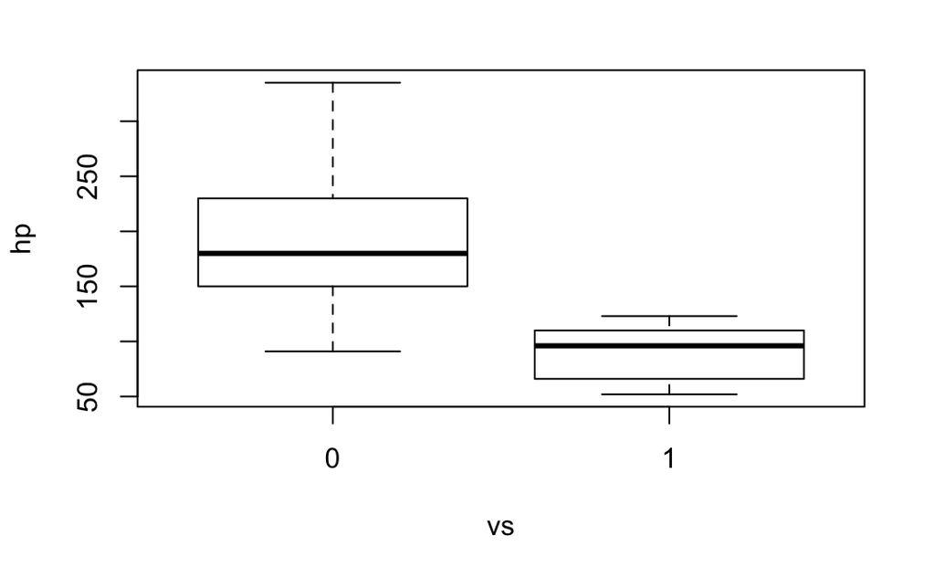

```r
t.test(hp ~ vs, data=mtcars)
```

```
    Welch Two Sample t-test

data:  hp by vs
t = 6.2908, df = 23.561, p-value = 1.82e-06
alternative hypothesis: true difference in means is not equal to 0
95 percent confidence interval:
  66.06161 130.66854
sample estimates:
mean in group 0 mean in group 1
      189.72222        91.35714
```

Then Let’s try to analyse **hp vs carb**.

```r
table(mtcars$carb)
```

```
 1  2  3  4  6  8
 7 10  3 10  1  1
```

```r
hp.model <- aov(hp ~ factor(carb), data=mtcars)
summary(hp.model)
```

```
             Df Sum Sq Mean Sq F value   Pr(>F)
factor(carb)  5  90319   18064   8.476 7.31e-05 ***
Residuals    26  55408    2131
---
Signif. codes:  0 ‘***’ 0.001 ‘**’ 0.01 ‘*’ 0.05 ‘.’ 0.1 ‘ ’ 1
```

## Simple plotting

If we would like to see the relations between mpg and hp, we could visualise it by *plot()*. This function will decide which plot will be good for the inputs by itself.

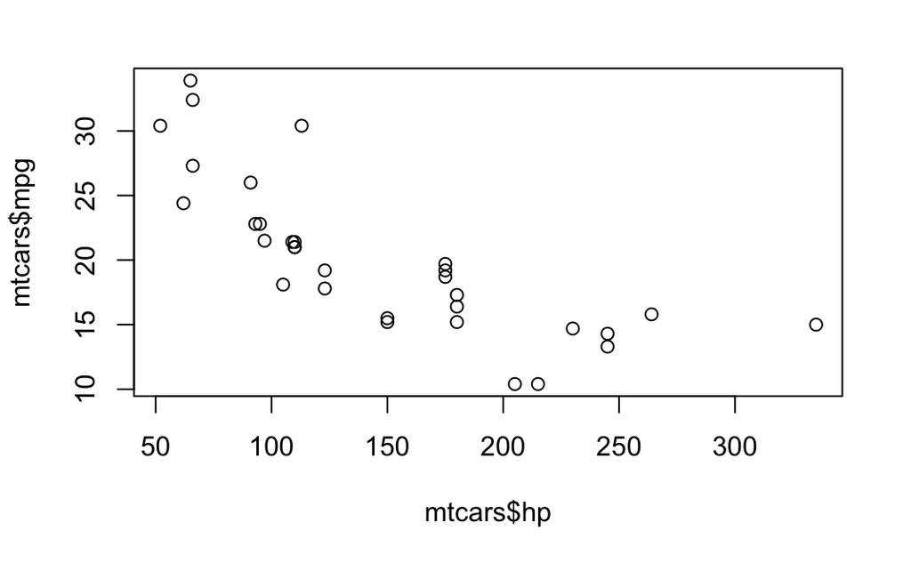

However, we could change the parameter **pch** to change the dot. To give the filled dots, pch = 19 will work.

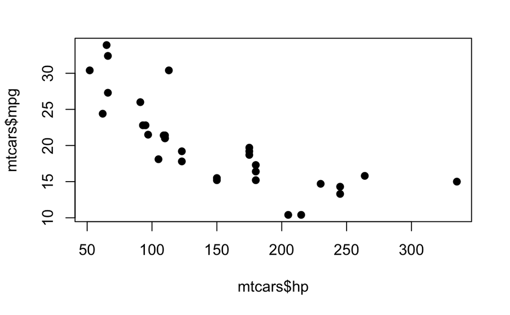

For plotting, using formula also works.

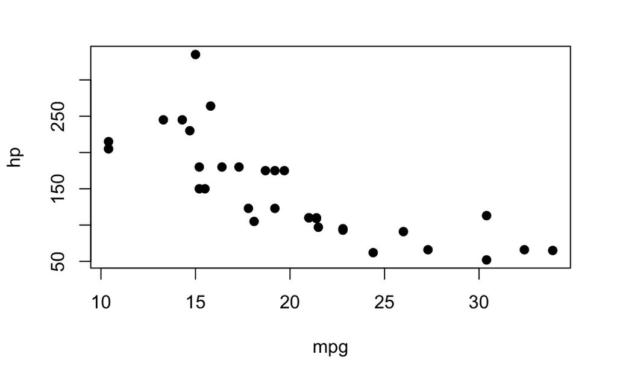

The advantage of using the formula is that we do not have to specify the name of axis because the function will take the name from the formula.

What if we would like to change the color? We could give the **col** parametre. It will give the color based on the gear information then!

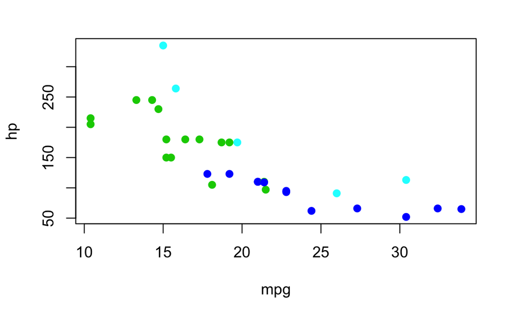

## Summarization of dataset

### Average

What if we would like to get the average hp for cars with different gears? *mean()* function will be helpful.

```r
mean(mtcars$hp)
```

```
[1] 146.6875
```

With this command, it will calculate the average value of hp for whole dataset. However, to get what we want, we should subset the dataset.

```r
# Creating logical vectors
is.gearEq3 <- mtcars$gear == 3
length(is.gearEq3)
```

```
[1] 32
```

```r
dim(mtcars.gear3)
```

```
[1] 15 11
```

Now we have the dataset much smaller than original one, and easy to be used for what we want to get.

Now we will make an average.

```r
mean(mtcars.gear3$hp)
```

```
[1] 176.1333
```

## Split-apply-combine

Most of analysis will work under the groups. Let’s think about the boxplot.

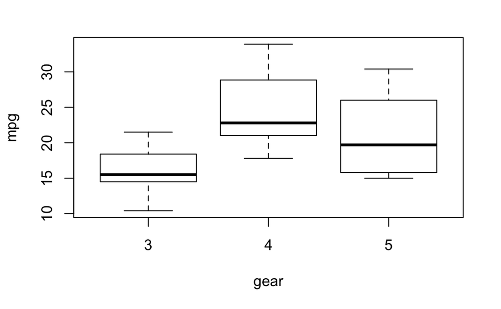

```r
boxplot(mpg ~ gear, data=mtcars)
```

It will split the gear information, apply plotting method and combind the informations on the plot!

One of the most important function is *aggregate()*, it splits the data into subsets, compute summary statistics for each, and returns the result in a convenient format, in other words, performing combination.

Here, the data will be splitted based on the gear information and apply *mean()* function on it. It will return the average value of hp for each gear information.

| gear | hp |
| --- | --- |
| 3 | 176.1333 |
| 4 | 89.5000 |
| 5 | 195.6000 |

Well, what if we would like to get standard deviation, not mean?

| gear | hp |
| --- | --- |
| 3 | 47.68927 |
| 4 | 25.89314 |
| 5 | 102.83385 |

## Sorting

Also we could **sort** dataset and keep the sorted data into environment. This could be worked with *dplyr* but it is also available with basic commands.

*order* will take a position of vectors into ascending order.

```r
order(mtcars$hp)
```

```
 [1] 19  8 20 18 26 27  3  9 21  6 32  1  2  4 28 10 11 22 23  5 25 30
[23] 12 13 14 15 16 17  7 24 29 31
```

So we could use this result to re-structure the dataset and re-arrange the dataset.

|  | mpg | cyl | disp | hp | drat | wt | qsec | vs | am | gear | carb |
| --- | --- | --- | --- | --- | --- | --- | --- | --- | --- | --- | --- |
| Honda Civic | 30.4 | 4 | 75.7 | 52 | 4.93 | 1.615 | 18.52 | 1 | 1 | 4 | 2 |
| Merc 240D | 24.4 | 4 | 146.7 | 62 | 3.69 | 3.190 | 20.00 | 1 | 0 | 4 | 2 |
| Toyota Corolla | 33.9 | 4 | 71.1 | 65 | 4.22 | 1.835 | 19.90 | 1 | 1 | 4 | 1 |
| Fiat 128 | 32.4 | 4 | 78.7 | 66 | 4.08 | 2.200 | 19.47 | 1 | 1 | 4 | 1 |
| Fiat X1-9 | 27.3 | 4 | 79.0 | 66 | 4.08 | 1.935 | 18.90 | 1 | 1 | 4 | 1 |
| Porsche 914-2 | 26.0 | 4 | 120.3 | 91 | 4.43 | 2.140 | 16.70 | 0 | 1 | 5 | 2 |
| Datsun 710 | 22.8 | 4 | 108.0 | 93 | 3.85 | 2.320 | 18.61 | 1 | 1 | 4 | 1 |
| Merc 230 | 22.8 | 4 | 140.8 | 95 | 3.92 | 3.150 | 22.90 | 1 | 0 | 4 | 2 |
| Toyota Corona | 21.5 | 4 | 120.1 | 97 | 3.70 | 2.465 | 20.01 | 1 | 0 | 3 | 1 |
| Valiant | 18.1 | 6 | 225.0 | 105 | 2.76 | 3.460 | 20.22 | 1 | 0 | 3 | 1 |

[output cut: 22 more lines]

What if we would like to sort the gear information in a manner of ascending of carb?

|  | mpg | cyl | disp | hp | drat | wt | qsec | vs | am | gear | carb |
| --- | --- | --- | --- | --- | --- | --- | --- | --- | --- | --- | --- |
| Hornet 4 Drive | 21.4 | 6 | 258.0 | 110 | 3.08 | 3.215 | 19.44 | 1 | 0 | 3 | 1 |
| Valiant | 18.1 | 6 | 225.0 | 105 | 2.76 | 3.460 | 20.22 | 1 | 0 | 3 | 1 |
| Toyota Corona | 21.5 | 4 | 120.1 | 97 | 3.70 | 2.465 | 20.01 | 1 | 0 | 3 | 1 |
| Hornet Sportabout | 18.7 | 8 | 360.0 | 175 | 3.15 | 3.440 | 17.02 | 0 | 0 | 3 | 2 |
| Dodge Challenger | 15.5 | 8 | 318.0 | 150 | 2.76 | 3.520 | 16.87 | 0 | 0 | 3 | 2 |
| AMC Javelin | 15.2 | 8 | 304.0 | 150 | 3.15 | 3.435 | 17.30 | 0 | 0 | 3 | 2 |
| Pontiac Firebird | 19.2 | 8 | 400.0 | 175 | 3.08 | 3.845 | 17.05 | 0 | 0 | 3 | 2 |
| Merc 450SE | 16.4 | 8 | 275.8 | 180 | 3.07 | 4.070 | 17.40 | 0 | 0 | 3 | 3 |
| Merc 450SL | 17.3 | 8 | 275.8 | 180 | 3.07 | 3.730 | 17.60 | 0 | 0 | 3 | 3 |
| Merc 450SLC | 15.2 | 8 | 275.8 | 180 | 3.07 | 3.780 | 18.00 | 0 | 0 | 3 | 3 |

[output cut: 22 more lines]

For descending, you could add minus sign (-) to the values.

|  | mpg | cyl | disp | hp | drat | wt | qsec | vs | am | gear | carb |
| --- | --- | --- | --- | --- | --- | --- | --- | --- | --- | --- | --- |
| Duster 360 | 14.3 | 8 | 360.0 | 245 | 3.21 | 3.570 | 15.84 | 0 | 0 | 3 | 4 |
| Cadillac Fleetwood | 10.4 | 8 | 472.0 | 205 | 2.93 | 5.250 | 17.98 | 0 | 0 | 3 | 4 |
| Lincoln Continental | 10.4 | 8 | 460.0 | 215 | 3.00 | 5.424 | 17.82 | 0 | 0 | 3 | 4 |
| Chrysler Imperial | 14.7 | 8 | 440.0 | 230 | 3.23 | 5.345 | 17.42 | 0 | 0 | 3 | 4 |
| Camaro Z28 | 13.3 | 8 | 350.0 | 245 | 3.73 | 3.840 | 15.41 | 0 | 0 | 3 | 4 |
| Merc 450SE | 16.4 | 8 | 275.8 | 180 | 3.07 | 4.070 | 17.40 | 0 | 0 | 3 | 3 |
| Merc 450SL | 17.3 | 8 | 275.8 | 180 | 3.07 | 3.730 | 17.60 | 0 | 0 | 3 | 3 |
| Merc 450SLC | 15.2 | 8 | 275.8 | 180 | 3.07 | 3.780 | 18.00 | 0 | 0 | 3 | 3 |
| Hornet Sportabout | 18.7 | 8 | 360.0 | 175 | 3.15 | 3.440 | 17.02 | 0 | 0 | 3 | 2 |
| Dodge Challenger | 15.5 | 8 | 318.0 | 150 | 2.76 | 3.520 | 16.87 | 0 | 0 | 3 | 2 |

[output cut: 22 more lines]

# Tidyverse

Why should we take care of **Tidyverse**? It is already highly structured and usability is better. Not only the code, but **grammer** for coding matters a lot! Also the readability of codes are obviously clear.

For tidyverse, regardless of the function, the first input should be dataset which we would like to put into the function.

## Verbs

Main five verbs provided by dplyr would be *arrange()*, *select()*, *filter()*, *summarise()* and *mutate()*. Also, sometimes *glimpse()* is also nice.

### arrange()

For *arrange()*, you should clarify the dataset, what to be arranged, the order for arrangement in the same group.

| mpg | cyl | disp | hp | drat | wt | qsec | vs | am | gear | carb |
| --- | --- | --- | --- | --- | --- | --- | --- | --- | --- | --- |
| 14.3 | 8 | 360.0 | 245 | 3.21 | 3.570 | 15.84 | 0 | 0 | 3 | 4 |
| 10.4 | 8 | 472.0 | 205 | 2.93 | 5.250 | 17.98 | 0 | 0 | 3 | 4 |
| 10.4 | 8 | 460.0 | 215 | 3.00 | 5.424 | 17.82 | 0 | 0 | 3 | 4 |
| 14.7 | 8 | 440.0 | 230 | 3.23 | 5.345 | 17.42 | 0 | 0 | 3 | 4 |
| 13.3 | 8 | 350.0 | 245 | 3.73 | 3.840 | 15.41 | 0 | 0 | 3 | 4 |
| 16.4 | 8 | 275.8 | 180 | 3.07 | 4.070 | 17.40 | 0 | 0 | 3 | 3 |
| 17.3 | 8 | 275.8 | 180 | 3.07 | 3.730 | 17.60 | 0 | 0 | 3 | 3 |
| 15.2 | 8 | 275.8 | 180 | 3.07 | 3.780 | 18.00 | 0 | 0 | 3 | 3 |
| 18.7 | 8 | 360.0 | 175 | 3.15 | 3.440 | 17.02 | 0 | 0 | 3 | 2 |
| 15.5 | 8 | 318.0 | 150 | 2.76 | 3.520 | 16.87 | 0 | 0 | 3 | 2 |

[output cut: 22 more lines]

### select()

This verb will be used to select some dataset. In other words, it is useful for subsetting of columns.

|  | hp | mpg |
| --- | --- | --- |
| Mazda RX4 | 110 | 21.0 |
| Mazda RX4 Wag | 110 | 21.0 |
| Datsun 710 | 93 | 22.8 |
| Hornet 4 Drive | 110 | 21.4 |
| Hornet Sportabout | 175 | 18.7 |
| Valiant | 105 | 18.1 |
| Duster 360 | 245 | 14.3 |
| Merc 240D | 62 | 24.4 |
| Merc 230 | 95 | 22.8 |
| Merc 280 | 123 | 19.2 |

[output cut: 22 more lines]

Also the **negative seletion** is possible.

|  | mpg | cyl | disp | drat | wt | qsec | vs | am | gear | carb |
| --- | --- | --- | --- | --- | --- | --- | --- | --- | --- | --- |
| Mazda RX4 | 21.0 | 6 | 160.0 | 3.90 | 2.620 | 16.46 | 0 | 1 | 4 | 4 |
| Mazda RX4 Wag | 21.0 | 6 | 160.0 | 3.90 | 2.875 | 17.02 | 0 | 1 | 4 | 4 |
| Datsun 710 | 22.8 | 4 | 108.0 | 3.85 | 2.320 | 18.61 | 1 | 1 | 4 | 1 |
| Hornet 4 Drive | 21.4 | 6 | 258.0 | 3.08 | 3.215 | 19.44 | 1 | 0 | 3 | 1 |
| Hornet Sportabout | 18.7 | 8 | 360.0 | 3.15 | 3.440 | 17.02 | 0 | 0 | 3 | 2 |
| Valiant | 18.1 | 6 | 225.0 | 2.76 | 3.460 | 20.22 | 1 | 0 | 3 | 1 |
| Duster 360 | 14.3 | 8 | 360.0 | 3.21 | 3.570 | 15.84 | 0 | 0 | 3 | 4 |
| Merc 240D | 24.4 | 4 | 146.7 | 3.69 | 3.190 | 20.00 | 1 | 0 | 4 | 2 |
| Merc 230 | 22.8 | 4 | 140.8 | 3.92 | 3.150 | 22.90 | 1 | 0 | 4 | 2 |
| Merc 280 | 19.2 | 6 | 167.6 | 3.92 | 3.440 | 18.30 | 1 | 0 | 4 | 4 |

[output cut: 22 more lines]

### filter()

| mpg | cyl | disp | hp | drat | wt | qsec | vs | am | gear | carb |
| --- | --- | --- | --- | --- | --- | --- | --- | --- | --- | --- |
| 21.4 | 6 | 258.0 | 110 | 3.08 | 3.215 | 19.44 | 1 | 0 | 3 | 1 |
| 18.7 | 8 | 360.0 | 175 | 3.15 | 3.440 | 17.02 | 0 | 0 | 3 | 2 |
| 18.1 | 6 | 225.0 | 105 | 2.76 | 3.460 | 20.22 | 1 | 0 | 3 | 1 |
| 14.3 | 8 | 360.0 | 245 | 3.21 | 3.570 | 15.84 | 0 | 0 | 3 | 4 |
| 16.4 | 8 | 275.8 | 180 | 3.07 | 4.070 | 17.40 | 0 | 0 | 3 | 3 |
| 17.3 | 8 | 275.8 | 180 | 3.07 | 3.730 | 17.60 | 0 | 0 | 3 | 3 |
| 15.2 | 8 | 275.8 | 180 | 3.07 | 3.780 | 18.00 | 0 | 0 | 3 | 3 |
| 10.4 | 8 | 472.0 | 205 | 2.93 | 5.250 | 17.98 | 0 | 0 | 3 | 4 |
| 10.4 | 8 | 460.0 | 215 | 3.00 | 5.424 | 17.82 | 0 | 0 | 3 | 4 |
| 14.7 | 8 | 440.0 | 230 | 3.23 | 5.345 | 17.42 | 0 | 0 | 3 | 4 |

[output cut: 5 more lines]

| mpg | cyl | disp | hp | drat | wt | qsec | vs | am | gear | carb |
| --- | --- | --- | --- | --- | --- | --- | --- | --- | --- | --- |
| 14.3 | 8 | 360 | 245 | 3.21 | 3.570 | 15.84 | 0 | 0 | 3 | 4 |
| 10.4 | 8 | 472 | 205 | 2.93 | 5.250 | 17.98 | 0 | 0 | 3 | 4 |
| 10.4 | 8 | 460 | 215 | 3.00 | 5.424 | 17.82 | 0 | 0 | 3 | 4 |
| 14.7 | 8 | 440 | 230 | 3.23 | 5.345 | 17.42 | 0 | 0 | 3 | 4 |
| 13.3 | 8 | 350 | 245 | 3.73 | 3.840 | 15.41 | 0 | 0 | 3 | 4 |

### mutate()

When we want to make any change on the column, especially adding new columns, we could use *mutate()* function.

Here as a example, we will put the ratio of mpg to hp as a new column. The new column wîll be added on the very end of the data.

| mpg | cyl | disp | hp | drat | wt | qsec | vs | am | gear | carb | mpg_hp_dplyr |
| --- | --- | --- | --- | --- | --- | --- | --- | --- | --- | --- | --- |
| 21.0 | 6 | 160.0 | 110 | 3.90 | 2.620 | 16.46 | 0 | 1 | 4 | 4 | 0.19090909 |
| 21.0 | 6 | 160.0 | 110 | 3.90 | 2.875 | 17.02 | 0 | 1 | 4 | 4 | 0.19090909 |
| 22.8 | 4 | 108.0 | 93 | 3.85 | 2.320 | 18.61 | 1 | 1 | 4 | 1 | 0.24516129 |
| 21.4 | 6 | 258.0 | 110 | 3.08 | 3.215 | 19.44 | 1 | 0 | 3 | 1 | 0.19454545 |
| 18.7 | 8 | 360.0 | 175 | 3.15 | 3.440 | 17.02 | 0 | 0 | 3 | 2 | 0.10685714 |
| 18.1 | 6 | 225.0 | 105 | 2.76 | 3.460 | 20.22 | 1 | 0 | 3 | 1 | 0.17238095 |
| 14.3 | 8 | 360.0 | 245 | 3.21 | 3.570 | 15.84 | 0 | 0 | 3 | 4 | 0.05836735 |
| 24.4 | 4 | 146.7 | 62 | 3.69 | 3.190 | 20.00 | 1 | 0 | 4 | 2 | 0.39354839 |
| 22.8 | 4 | 140.8 | 95 | 3.92 | 3.150 | 22.90 | 1 | 0 | 4 | 2 | 0.24000000 |
| 19.2 | 6 | 167.6 | 123 | 3.92 | 3.440 | 18.30 | 1 | 0 | 4 | 4 | 0.15609756 |

[output cut: 22 more lines]

Also the *mutate()* works for several addition.

| mpg | cyl | disp | hp | drat | wt | qsec | vs | am | gear | carb | mpg_hp_dplyr | mpg_wt |
| --- | --- | --- | --- | --- | --- | --- | --- | --- | --- | --- | --- | --- |
| 21.0 | 6 | 160.0 | 110 | 3.90 | 2.620 | 16.46 | 0 | 1 | 4 | 4 | 0.19090909 | 8.015267 |
| 21.0 | 6 | 160.0 | 110 | 3.90 | 2.875 | 17.02 | 0 | 1 | 4 | 4 | 0.19090909 | 7.304348 |
| 22.8 | 4 | 108.0 | 93 | 3.85 | 2.320 | 18.61 | 1 | 1 | 4 | 1 | 0.24516129 | 9.827586 |
| 21.4 | 6 | 258.0 | 110 | 3.08 | 3.215 | 19.44 | 1 | 0 | 3 | 1 | 0.19454545 | 6.656299 |
| 18.7 | 8 | 360.0 | 175 | 3.15 | 3.440 | 17.02 | 0 | 0 | 3 | 2 | 0.10685714 | 5.436047 |
| 18.1 | 6 | 225.0 | 105 | 2.76 | 3.460 | 20.22 | 1 | 0 | 3 | 1 | 0.17238095 | 5.231214 |
| 14.3 | 8 | 360.0 | 245 | 3.21 | 3.570 | 15.84 | 0 | 0 | 3 | 4 | 0.05836735 | 4.005602 |
| 24.4 | 4 | 146.7 | 62 | 3.69 | 3.190 | 20.00 | 1 | 0 | 4 | 2 | 0.39354839 | 7.648903 |
| 22.8 | 4 | 140.8 | 95 | 3.92 | 3.150 | 22.90 | 1 | 0 | 4 | 2 | 0.24000000 | 7.238095 |
| 19.2 | 6 | 167.6 | 123 | 3.92 | 3.440 | 18.30 | 1 | 0 | 4 | 4 | 0.15609756 | 5.581395 |

[output cut: 22 more lines]

### summarise()

It is similar to split-apply-combination concept, especially when working with *group_by()* manner. The name of output and operation should be specified

| gear | meanHP |
| --- | --- |
| 3 | 176.1333 |
| 4 | 89.5000 |
| 5 | 195.6000 |

Not like *aggregate()*, we do not call the *summarise()* several times.

| gear | meanHP | sdHP |
| --- | --- | --- |
| 3 | 176.1333 | 47.68927 |
| 4 | 89.5000 | 25.89314 |
| 5 | 195.6000 | 102.83385 |

The another version is available, called *summarise_all()*. What if we would like to get all the average, but still consider the group? Just specify which function you would like to run as a input of *summarise_all()*.

```r
mtcars %>%
  group_by(gear) %>%
  summarise_all(mean)
```

| gear | mpg | cyl | disp | hp | drat | wt | qsec | vs | am | carb |
| --- | --- | --- | --- | --- | --- | --- | --- | --- | --- | --- |
| 3 | 16.10667 | 7.466667 | 326.3000 | 176.1333 | 3.132667 | 3.892600 | 17.692 | 0.2000000 | 0.0000000 | 2.666667 |
| 4 | 24.53333 | 4.666667 | 123.0167 | 89.5000 | 4.043333 | 2.616667 | 18.965 | 0.8333333 | 0.6666667 | 2.333333 |
| 5 | 21.38000 | 6.000000 | 202.4800 | 195.6000 | 3.916000 | 2.632600 | 15.640 | 0.2000000 | 1.0000000 | 4.400000 |

### glimpse()

*glimpse()* is more or less similar to *str()*, it shows all the information about the dataset.

```r
glimpse(mtcars)
```

```
Observations: 32
Variables: 11
$ mpg  <dbl> 21.0, 21.0, 22.8, 21.4, 18.7, 18.1, 14.3, 24.4, 22.8, 1…
$ cyl  <dbl> 6, 6, 4, 6, 8, 6, 8, 4, 4, 6, 6, 8, 8, 8, 8, 8, 8, 4, 4…
$ disp <dbl> 160.0, 160.0, 108.0, 258.0, 360.0, 225.0, 360.0, 146.7,…
$ hp   <dbl> 110, 110, 93, 110, 175, 105, 245, 62, 95, 123, 123, 180…
$ drat <dbl> 3.90, 3.90, 3.85, 3.08, 3.15, 2.76, 3.21, 3.69, 3.92, 3…
$ wt   <dbl> 2.620, 2.875, 2.320, 3.215, 3.440, 3.460, 3.570, 3.190,…
$ qsec <dbl> 16.46, 17.02, 18.61, 19.44, 17.02, 20.22, 15.84, 20.00,…
$ vs   <dbl> 0, 0, 1, 1, 0, 1, 0, 1, 1, 1, 1, 0, 0, 0, 0, 0, 0, 1, 1…
$ am   <dbl> 1, 1, 1, 0, 0, 0, 0, 0, 0, 0, 0, 0, 0, 0, 0, 0, 0, 1, 1…
$ gear <dbl> 4, 4, 4, 3, 3, 3, 3, 4, 4, 4, 4, 3, 3, 3, 3, 3, 3, 4, 4…
$ carb <dbl> 4, 4, 1, 1, 2, 1, 4, 2, 2, 4, 4, 3, 3, 3, 4, 4, 4, 1, 2…
```

## Pipe operator

Pipe operator could connect the two different commands. It could be typed by shift + command + m and the format is %>% .

When the function is given with pipe operator, the rond bracket () is not required anymore.

```r
mtcars$hp %>% log10
```

```
 [1] 2.041393 2.041393 1.968483 2.041393 2.243038 2.021189 2.389166
 [8] 1.792392 1.977724 2.089905 2.089905 2.255273 2.255273 2.255273
[15] 2.311754 2.332438 2.361728 1.819544 1.716003 1.812913 1.986772
[22] 2.176091 2.176091 2.389166 2.243038 1.819544 1.959041 2.053078
[29] 2.421604 2.243038 2.525045 2.037426
```

```r
mtcars$hp %>% log10 %>% sin
```

```
 [1] 0.8912980 0.8912980 0.9219594 0.8912980 0.7824276 0.9002761
 [7] 0.6834122 0.9755481 0.9183413 0.8682617 0.8682617 0.7747503
[13] 0.7747503 0.7747503 0.7378226 0.7237037 0.7031833 0.9692215
[19] 0.9894760 0.9708326 0.9147226 0.8223343 0.8223343 0.6834122
[25] 0.7824276 0.9692215 0.9255748 0.8859388 0.6593762 0.7824276
[31] 0.5782221 0.8930894
```

### Example

#### Step by step

```r
mtcars.new <- mtcars
mtcars.new$carname <- rownames(mtcars)
head(mtcars.new)
```

|  | mpg | cyl | disp | hp | drat | wt | qsec | vs | am | gear | carb | carname |
| --- | --- | --- | --- | --- | --- | --- | --- | --- | --- | --- | --- | --- |
| Mazda RX4 | 21.0 | 6 | 160 | 110 | 3.90 | 2.620 | 16.46 | 0 | 1 | 4 | 4 | Mazda RX4 |
| Mazda RX4 Wag | 21.0 | 6 | 160 | 110 | 3.90 | 2.875 | 17.02 | 0 | 1 | 4 | 4 | Mazda RX4 Wag |
| Datsun 710 | 22.8 | 4 | 108 | 93 | 3.85 | 2.320 | 18.61 | 1 | 1 | 4 | 1 | Datsun 710 |
| Hornet 4 Drive | 21.4 | 6 | 258 | 110 | 3.08 | 3.215 | 19.44 | 1 | 0 | 3 | 1 | Hornet 4 Drive |
| Hornet Sportabout | 18.7 | 8 | 360 | 175 | 3.15 | 3.440 | 17.02 | 0 | 0 | 3 | 2 | Hornet Sportabout |
| Valiant | 18.1 | 6 | 225 | 105 | 2.76 | 3.460 | 20.22 | 1 | 0 | 3 | 1 | Valiant |

```r
mazda.cars <- filter(mtcarrs.new, carname == "Mazda RX4" )
```

[output not shown]

| hp | mpg |
| --- | --- |
| 110 | 21 |

#### using pipe operator

| hp | mpg |
| --- | --- |
| 110 | 21 |

| hp | mpg |
| --- | --- |
| 97 | 21.5 |
| 105 | 18.1 |
| 110 | 21.4 |
| 150 | 15.5 |
| 150 | 15.2 |
| 175 | 19.2 |
| 175 | 18.7 |
| 180 | 17.3 |
| 180 | 16.4 |
| 180 | 15.2 |

[output cut: 5 more lines]

Q. Cars with hp/mpg greater than 9 + what are the gears + make a table and pie chart

```r
mtcars %>%
  mutate(hp_mpg = hp / mpg) %>%
  filter(hp_mpg > 9) %>%
  select(gear) %>%
  table
```

```
.
 3  5
12  2
```

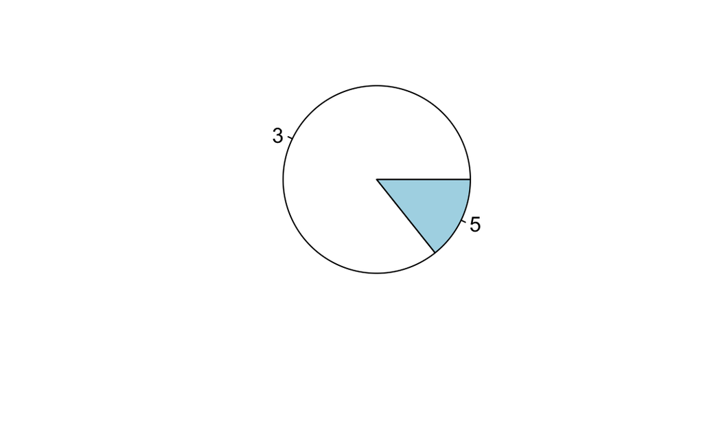

For the dataset generated by using several pipes, it is also available to save it as a new variable. There are two ways of saving.

```r
mtcars %>%
  filter(gear == 3) %>%
  filter(wt > 2) %>%
  select(hp, mpg) %>%
  arrange(hp, desc(mpg)) -> data.final
```

```r
data.final <- mtcars %>%
  filter(gear == 3) %>%
  filter(wt > 2) %>%
  select(hp, mpg) %>%
  arrange(hp, desc(mpg))
```